# STAT 253 Final Project

Jacob, Julian, Aristo, and Emily

October 17, 2022

# Library Statements

```r
library(ISLR)
library(dplyr)
library(readr)
library(broom)
library(ggplot2)
library(tidymodels)
library(stringr)
library(splitstackshape)
library(tidymodels)
library(lubridate)
library(rpart.plot)
library(cluster)
library(forcats)
tidymodels_prefer()
```

# Read in Data

```r
library(readr)
imdb_top_1000 <- read_csv("~/Desktop/Statistical Machine Learning/R Files/Final Project/imdb_top_1000.csv")
```

# Data Cleaning

```r
imdb_clean <- imdb_top_1000 %>%
  select(-Poster_Link, -Certificate) %>%
  cSplit("Genre", sep = ",", direction = "wide") %>%
  mutate(Gross = log(Gross))

runtime_clean <- imdb_top_1000$Runtime %>%
  str_replace(" min", "") %>%
  as.numeric()

imdb_clean$Runtime <- runtime_clean
```

# Creation of CV Folds

```r
data_cv10 <- vfold_cv(imdb_clean, v = 10)
```

# Model Spec for Linear Regression Model

```r
lm_spec <-
    linear_reg() %>%
    set_engine(engine = 'lm') %>%
    set_mode('regression')
```

# Recipes and Workflows

```r
full_rec <- recipe(Gross ~ ., data = imdb_clean) %>%
    step_rm(Series_Title, Released_Year, Overview,
            Director, Star1, Star2, Star3, Star4, Genre_2, Genre_3) %>% #variables causing issues
    step_nzv(all_predictors()) %>%
    step_normalize(all_numeric_predictors()) %>%
    step_dummy(all_nominal_predictors()) %>%
    step_naomit(Gross)

full_lm_wf <- workflow() %>%
    add_recipe(full_rec) %>%
    add_model(lm_spec)

full_model <- fit(full_lm_wf, data = imdb_clean)

full_modelcv <- fit_resamples(full_lm_wf, resamples = data_cv10, metrics = metric_set(rmse, rsq, mae))

full_model %>% tidy()
```

| term | estimate | std.error | statistic | p.value |
| --- | --- | --- | --- | --- |
| (Intercept) | 16.5002859489 | 0.16306477 | 1.011885e+02 | 0.000000e+00 |
| Runtime | 0.3911907246 | 0.07610517 | 5.140134e+00 | 3.525062e-07 |
| IMDB_Rating | -0.9950928006 | 0.08336393 | -1.193673e+01 | 3.862311e-30 |
| Meta_score | 0.1813014879 | 0.06648385 | 2.727000e+00 | 6.544109e-03 |
| No_of_Votes | 1.5909990747 | 0.07963205 | 1.997938e+01 | 3.131295e-71 |
| Genre_1_Adventure | -0.0001967664 | 0.27081934 | -7.265595e-04 | 9.994205e-01 |
| Genre_1_Animation | 0.5973811514 | 0.27614579 | 2.163282e+00 | 3.084205e-02 |
| Genre_1_Biography | 0.5941597905 | 0.25339230 | 2.344822e+00 | 1.930208e-02 |
| Genre_1_Comedy | -0.1412117537 | 0.23393639 | -6.036331e-01 | 5.462743e-01 |
| Genre_1_Crime | -0.8944072772 | 0.24494930 | -3.651398e+00 | 2.793667e-04 |

[output cut: 8 more lines]

# LASSO - Fit and Tune Models

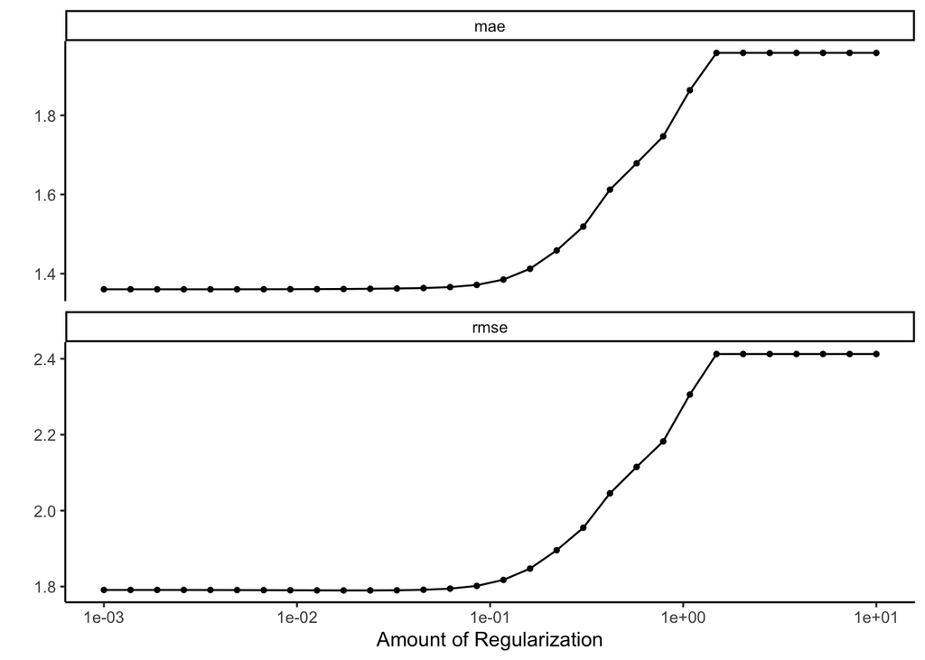

```r
# Lasso Model Spec with tune
lm_lasso_spec_tune <-
  linear_reg() %>%
  set_args(mixture = 1, penalty = tune()) %>% ## mixture = 1 indicates Lasso
  set_engine(engine = 'glmnet') %>% #note we are using a different engine
  set_mode('regression')

# Recipe with standardization (!) --> just include all these always
data_rec <- recipe(Gross ~ ., data = imdb_clean) %>%
    step_rm(Series_Title, Released_Year, Overview,
            Director, Star1, Star2, Star3, Star4, Genre_2, Genre_3) %>%
    step_nzv(all_predictors()) %>% # removes variables with the same value (so duplicates don't mess up model)
    step_novel(all_nominal_predictors()) %>% # important if you have rare categorical variables
    step_normalize(all_numeric_predictors()) %>%  # super important standardization step for LASSO
    step_dummy(all_nominal_predictors()) %>%  # creates indicator variables for categorical variables
    step_naomit(Gross)

# Workflow (Recipe + Model)
lasso_wf_tune <- workflow() %>%
  add_recipe(data_rec) %>%
  add_model(lm_lasso_spec_tune)

# Tune Model (trying a variety of values of Lambda penalty)
penalty_grid <- grid_regular(
  penalty(range = c(-3, 1)),
  levels = 30)

tune_res <- tune_grid( # new function for tuning parameters
  lasso_wf_tune, # workflow
  resamples = data_cv10, # cv folds
  metrics = metric_set(rmse, mae),
  grid = penalty_grid # penalty grid defined above
)

# Visualize Model Evaluation Metrics from Tuning
autoplot(tune_res) + theme_classic()
```

# Collect CV Metrics and Select Best Model

```r
# Summarize Model Evaluation Metrics (CV)
lasso_mod <- collect_metrics(tune_res) %>%
  filter(.metric == 'rmse') %>% # or choose mae
  select(penalty, rmse = mean)

best_penalty <- select_best(tune_res, metric = 'rmse') # choose penalty value based on lowest mae or rmse

lasso_mod
```

| penalty | rmse |
| --- | --- |
| 0.001000000 | 1.791129 |
| 0.001373824 | 1.791129 |
| 0.001887392 | 1.791129 |
| 0.002592944 | 1.791108 |
| 0.003562248 | 1.790977 |
| 0.004893901 | 1.790812 |
| 0.006723358 | 1.790577 |
| 0.009236709 | 1.790305 |
| 0.012689610 | 1.790023 |
| 0.017433288 | 1.789810 |

[output cut: 20 more lines]

# Fit Final Model

```r
# Fit Final Model
final_wf <- finalize_workflow(lasso_wf_tune, best_penalty) # incorporates penalty value to workflow

final_fit <- fit(final_wf, data = imdb_clean)

lasso_fit <- fit_resamples(final_wf, resamples = data_cv10, metrics = metric_set(rmse, rsq, mae))

tidy(final_fit)
```

| term | estimate | penalty |
| --- | --- | --- |
| (Intercept) | 16.25867291 | 0.01743329 |
| Runtime | 0.31320626 | 0.01743329 |
| IMDB_Rating | -0.98112595 | 0.01743329 |
| Meta_score | 0.00000000 | 0.01743329 |
| No_of_Votes | 1.68100163 | 0.01743329 |
| Genre_1_Adventure | 0.21379158 | 0.01743329 |
| Genre_1_Animation | 0.68189096 | 0.01743329 |
| Genre_1_Biography | 0.56984397 | 0.01743329 |
| Genre_1_Comedy | -0.03005227 | 0.01743329 |
| Genre_1_Crime | -0.74108695 | 0.01743329 |

[output cut: 9 more lines]

```r
# Final ("best") model predictors and coefficients

final_fit %>% tidy() %>% filter(estimate != 0)
```

| term | estimate | penalty |
| --- | --- | --- |
| (Intercept) | 16.25867291 | 0.01743329 |
| Runtime | 0.31320626 | 0.01743329 |
| IMDB_Rating | -0.98112595 | 0.01743329 |
| No_of_Votes | 1.68100163 | 0.01743329 |
| Genre_1_Adventure | 0.21379158 | 0.01743329 |
| Genre_1_Animation | 0.68189096 | 0.01743329 |
| Genre_1_Biography | 0.56984397 | 0.01743329 |
| Genre_1_Comedy | -0.03005227 | 0.01743329 |
| Genre_1_Crime | -0.74108695 | 0.01743329 |
| Genre_1_Drama | -0.39102430 | 0.01743329 |

[output cut: 6 more lines]

# Visualize Residuals

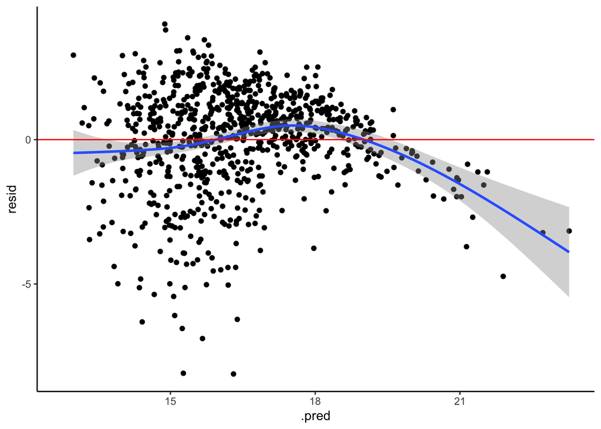

```r
# Visualize Residuals
lasso_mod_out <- final_fit %>%
    predict(new_data = imdb_clean) %>%
    bind_cols(imdb_clean) %>%
    mutate(resid = Gross - .pred)

ggplot(lasso_mod_out, aes(x = .pred, y = resid)) +
    geom_point() +
    geom_smooth() +
    geom_hline(yintercept = 0, color = "red") +
    theme_classic()
```

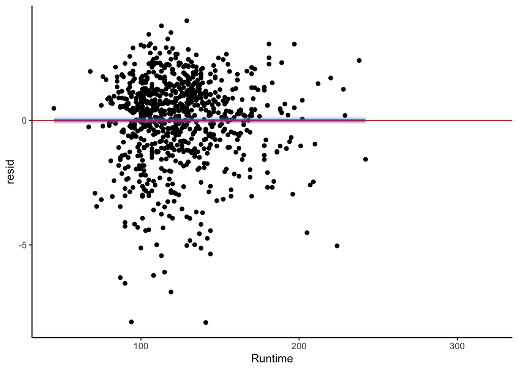

```r
ggplot(lasso_mod_out, aes(x = Runtime, y = resid)) +
    geom_point() +
    geom_smooth() +
    geom_hline(yintercept = 0, color = "red") +
    theme_classic()
```

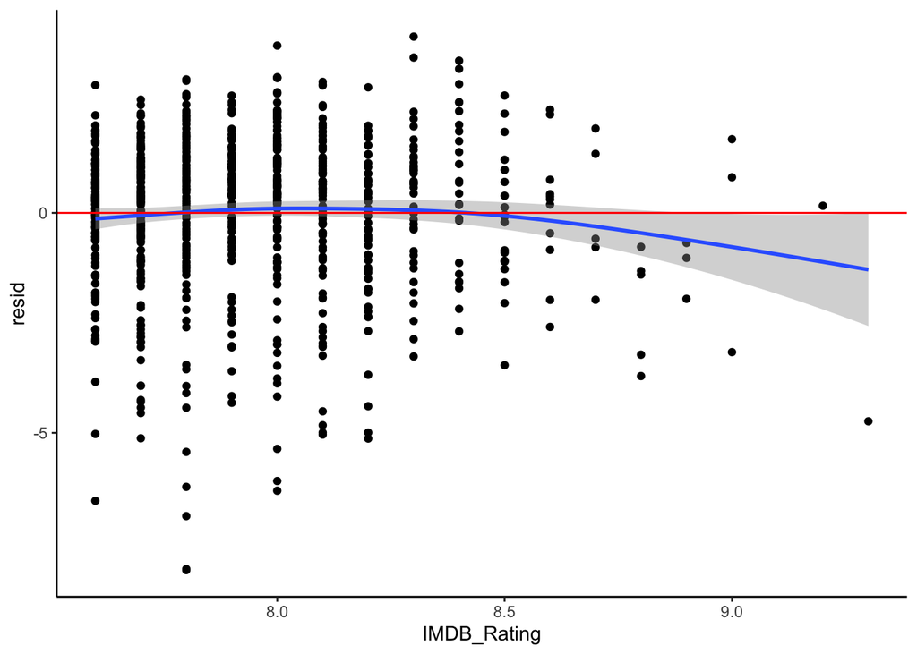

```r
ggplot(lasso_mod_out, aes(x = IMDB_Rating, y = resid)) +
    geom_point() +
    geom_smooth() +
    geom_hline(yintercept = 0, color = "red") +
    theme_classic()
```

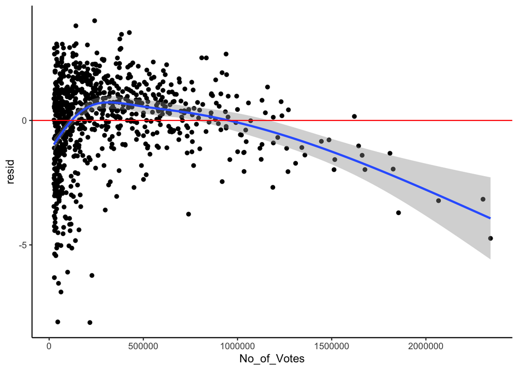

```r
ggplot(lasso_mod_out, aes(x = No_of_Votes, y = resid)) +
    geom_point() +
    geom_smooth() +
    geom_hline(yintercept = 0, color = "red") +
    theme_classic()
```

The main caution we want to keep in mind when communicating our work is that our model may be bias against new names in the movie industry. The model cannot determine a director, actor, or actresses’ talent. It only bases its predictions off of how previous movies that individual was involved in previously performed. Furthermore, the inclusion of the number of votes predictor in our model raises further concerns of potential bias. Our initial evaluation of the residual vs. predictor plot revealed a textbook case of heteroscedasticity. Performing a log transformation on our outcome variable, gross revenue, improved this issue. However, there is still a slight pattern noticeable in the residual vs. predictor plot. Analysis of the residual vs. quantitative predictor plots reveals the number of votes predictor as the likely source of this error. The caution to keep in mind with the inclusion of this predictor is the idea of participation bias. In further investigations, we intend to evaluate whether to “override” the LASSO results and exclude the number of votes predictor from the model if we determine that it is introducing bias into our model.

It is also important to consider any harms that may come from our analyses. Analyzing and predicting gross revenue of movies can have harmful effects on the performance of movies in box offices. For example, if we use our model to predict the success of a new movie, our model’s prediction may affect people’s decision as to whether or not to see the movie. This could affect the actual outcome of how movies perform at the box office by introducing bias into people’s decision regarding whether to see a newly released movie.

# GAMs Using Splines

```r
# Build the GAM

gam_spec <-
  gen_additive_mod() %>%
  set_engine(engine = 'mgcv') %>%
  set_mode('regression')

gam_mod <- fit(gam_spec,
    Gross ~ s(Runtime) + IMDB_Rating + s(Meta_score) + s(No_of_Votes) + Genre_1,
    data = imdb_clean
)
```

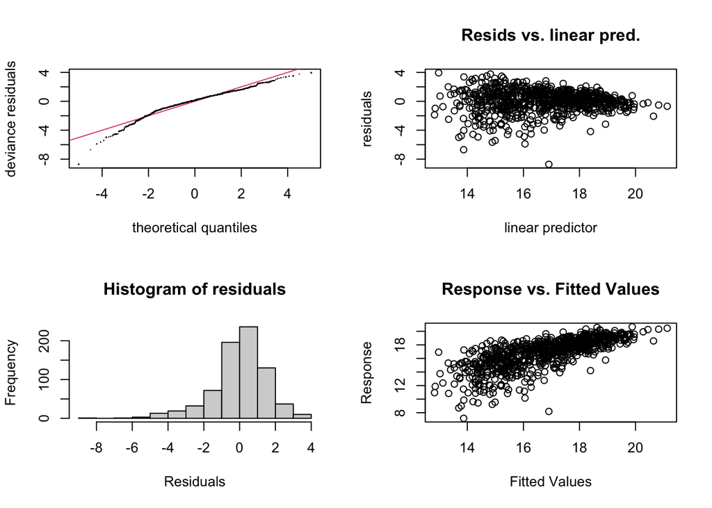

```
##
## Method: GCV   Optimizer: magic
## Smoothing parameter selection converged after 9 iterations.
## The RMS GCV score gradient at convergence was 1.347653e-06 .
## The Hessian was positive definite.
## Model rank =  41 / 41
##
## Basis dimension (k) checking results. Low p-value (k-index<1) may
## indicate that k is too low, especially if edf is close to k'.
##
##                  k'  edf k-index p-value
## s(Runtime)     9.00 2.06    0.95   0.095 .
## s(Meta_score)  9.00 2.38    0.96   0.140
## s(No_of_Votes) 9.00 6.18    0.98   0.285
## ---
## Signif. codes:  0 '***' 0.001 '**' 0.01 '*' 0.05 '.' 0.1 ' ' 1
```

```r
# Diagnostics: Check to see if the number of knots is large enough (if p-value is low, increase number of knots)

gam_mod %>% pluck('fit') %>% mgcv::gam.check()
```

```r
gam_mod %>% pluck('fit') %>% summary()
```

```
##
## Family: gaussian
## Link function: identity
##
## Formula:
## Gross ~ s(Runtime) + IMDB_Rating + s(Meta_score) + s(No_of_Votes) +
##     Genre_1
##
## Parametric coefficients:
##                  Estimate Std. Error t value Pr(>|t|)
## (Intercept)      40.48393    2.28309  17.732  < 2e-16 ***
## IMDB_Rating      -2.98188    0.28990 -10.286  < 2e-16 ***
## Genre_1Adventure -0.08215    0.25202  -0.326 0.744537
## Genre_1Animation  0.63404    0.26136   2.426 0.015512 *
## Genre_1Biography  0.47026    0.23502   2.001 0.045776 *
## Genre_1Comedy    -0.03057    0.21855  -0.140 0.888787
## Genre_1Crime     -0.80973    0.22677  -3.571 0.000379 ***
## Genre_1Drama     -0.33315    0.18688  -1.783 0.075058 .
## Genre_1Family     0.35535    1.11864   0.318 0.750829
## Genre_1Film-Noir -1.67964    1.13010  -1.486 0.137643
## Genre_1Horror     0.03651    0.52191   0.070 0.944244
## Genre_1Mystery   -0.74005    0.61320  -1.207 0.227873
## Genre_1Thriller   1.93442    1.57867   1.225 0.220841
## Genre_1Western    0.03749    0.81131   0.046 0.963155
## ---
## Signif. codes:  0 '***' 0.001 '**' 0.01 '*' 0.05 '.' 0.1 ' ' 1
##
## Approximate significance of smooth terms:
##                  edf Ref.df      F  p-value
## s(Runtime)     2.065  2.642 13.099 6.74e-07 ***
## s(Meta_score)  2.380  3.029  5.921 0.000523 ***
## s(No_of_Votes) 6.183  7.328 74.397  < 2e-16 ***
## ---
## Signif. codes:  0 '***' 0.001 '**' 0.01 '*' 0.05 '.' 0.1 ' ' 1
##
## R-sq.(adj) =  0.516   Deviance explained = 53.2%
## GCV = 2.5279  Scale est. = 2.4448    n = 750
```

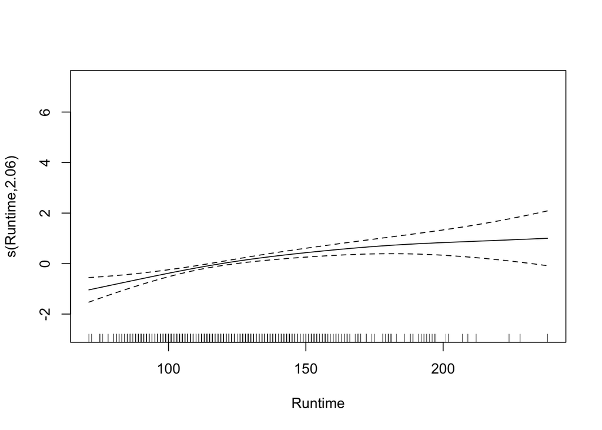

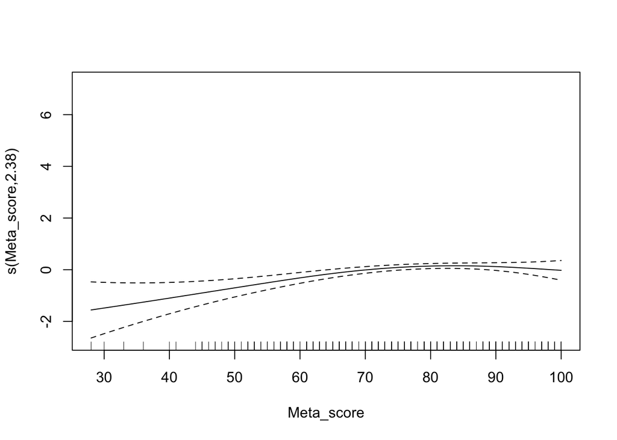

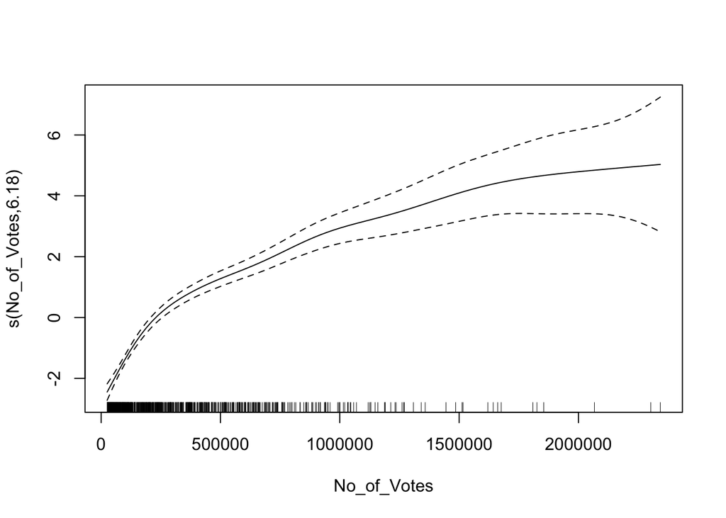

```r
# Visualize: Look at the estimated non-linear functions

gam_mod %>% pluck('fit') %>% plot()
```

```r
spline_rec <- recipe(Gross ~ ., data = imdb_clean) %>%
    step_rm(Series_Title, Released_Year, Overview,
            Director, Star1, Star2, Star3, Star4, Genre_2, Genre_3) %>% #variables causing issues
    step_nzv(all_predictors()) %>%
    step_normalize(all_numeric_predictors()) %>%
    step_dummy(all_nominal_predictors()) %>%
    step_naomit(Gross) %>%
    step_ns(Runtime, deg_free = 2) %>%
    step_ns(No_of_Votes, deg_free = 6)


spline_rec %>% prep(imdb_clean) %>% juice()
```

| IMDB_Rating | Meta_score | Gross | Genre_1_Adventure | Genre_1_Animation | Genre_1_Biography | Genre_1_Comedy | Genre_1_Crime | Genre_1_Drama | Genre_1_Family | Genre_1_Fantasy | Genre_1_Film.Noir | Genre_1_Horror | Genre_1_Mystery | Genre_1_Thriller | Genre_1_Western | Runtime_ns_1 | Runtime_ns_2 | No_of_Votes_ns_1 | No_of_Votes_ns_2 | No_of_Votes_ns_3 | No_of_Votes_ns_4 | No_of_Votes_ns_5 | No_of_Votes_ns_6 |
| --- | --- | --- | --- | --- | --- | --- | --- | --- | --- | --- | --- | --- | --- | --- | --- | --- | --- | --- | --- | --- | --- | --- | --- |
| 4.9028788 | 0.163902187 | 17.159837 | 0 | 0 | 0 | 0 | 0 | 1 | 0 | 0 | 0 | 0 | 0 | 0 | 0 | 0.5737267 | -0.164314832 | 0.000000e+00 | 0.000000e+00 | 0.000000e+00 | -1.656467e-01 | 3.553885e-01 | 8.102583e-01 |
| 4.5398908 | 1.779920245 | 18.720536 | 0 | 0 | 0 | 0 | 1 | 0 | 0 | 0 | 0 | 0 | 0 | 0 | 0 | 0.5545783 | 0.066652487 | 0.000000e+00 | 0.000000e+00 | 4.989807e-02 | 3.519942e-01 | 3.151407e-01 | 2.829671e-01 |
| 3.8139148 | 0.487105799 | 20.097513 | 0 | 0 | 0 | 0 | 0 | 0 | 0 | 0 | 0 | 0 | 0 | 0 | 0 | 0.5786194 | -0.108639462 | 0.000000e+00 | 0.000000e+00 | 8.381701e-06 | -1.331281e-01 | 3.539482e-01 | 7.791715e-01 |
| 3.8139148 | 0.971911216 | 17.863811 | 0 | 0 | 0 | 0 | 1 | 0 | 0 | 0 | 0 | 0 | 0 | 0 | 0 | 0.4782356 | 0.336835364 | 0.000000e+00 | 0.000000e+00 | 2.359849e-01 | 4.837627e-01 | 2.445458e-01 | 3.570669e-02 |
| 3.8139148 | 1.456716634 | 15.287983 | 0 | 0 | 0 | 0 | 1 | 0 | 0 | 0 | 0 | 0 | 0 | 0 | 0 | 0.4011817 | -0.219607313 | 0.000000e+00 | 0.000000e+00 | 5.972545e-01 | 3.219228e-01 | 1.259532e-01 | -4.513055e-02 |
| 3.4509268 | 1.295114828 | 19.749997 | 0 | 0 | 0 | 0 | 0 | 0 | 0 | 0 | 0 | 0 | 0 | 0 | 0 | 0.4817594 | 0.325896717 | 0.000000e+00 | 0.000000e+00 | 4.540265e-02 | 3.402098e-01 | 3.172262e-01 | 2.971613e-01 |
| 3.4509268 | 1.295114828 | 18.496982 | 0 | 0 | 0 | 0 | 1 | 0 | 0 | 0 | 0 | 0 | 0 | 0 | 0 | 0.5783907 | -0.095888624 | 0.000000e+00 | 0.000000e+00 | 1.825606e-02 | 2.297144e-01 | 3.315590e-01 | 4.204705e-01 |
| 3.4509268 | 1.295114828 | 18.389178 | 0 | 0 | 1 | 0 | 0 | 0 | 0 | 0 | 0 | 0 | 0 | 0 | 0 | 0.5019292 | 0.261566745 | 0.000000e+00 | 0.000000e+00 | 1.905074e-01 | 4.811709e-01 | 2.604895e-01 | 6.783220e-02 |
| 3.0879388 | -0.320903230 | 19.494236 | 0 | 0 | 0 | 0 | 0 | 0 | 0 | 0 | 0 | 0 | 0 | 0 | 0 | 0.5778956 | -0.132560248 | 0.000000e+00 | 0.000000e+00 | 2.780867e-03 | 5.554783e-02 | 3.446437e-01 | 5.970276e-01 |
| 3.0879388 | -0.967310453 | 17.427242 | 0 | 0 | 0 | 0 | 0 | 1 | 0 | 0 | 0 | 0 | 0 | 0 | 0 | 0.5701913 | -0.178250156 | 0.000000e+00 | 0.000000e+00 | 1.539497e-02 | 2.105479e-01 | 3.334020e-01 | 4.406551e-01 |

[output cut: 821 more lines]

```r
# Use the edf (round to integer) from above to create a recipe by adding step_ns() for the variables you want model with a non-linear relationship and do CV. Compare this model to one without any splines.

lm_spec_gam <-
  linear_reg() %>%
  set_engine(engine = 'lm') %>%
  set_mode('regression')


spline_wf <- workflow() %>%
    add_model(lm_spec) %>%
    add_recipe(spline_rec)

cv_output <- fit_resamples(
  spline_wf, # workflow
  resamples = data_cv10, # cv folds
  metrics = metric_set(mae,rmse,rsq)
)

cv_output %>% collect_metrics()
```

| .metric | .estimator | mean | n | std_err | .config |
| --- | --- | --- | --- | --- | --- |
| mae | standard | 1.1628028 | 10 | 0.03399182 | Preprocessor1_Model1 |
| rmse | standard | 1.5892078 | 10 | 0.05245617 | Preprocessor1_Model1 |
| rsq | standard | 0.4967594 | 10 | 0.01698366 | Preprocessor1_Model1 |

```r
new_mod <- spline_wf %>%
  fit(data = imdb_clean)

new_mod %>%
  tidy()
```

| term | estimate | std.error | statistic | p.value |
| --- | --- | --- | --- | --- |
| (Intercept) | 11.66941369 | 0.57456917 | 20.30985007 | 5.547687e-73 |
| IMDB_Rating | -0.86128146 | 0.07883594 | -10.92498464 | 7.855435e-26 |
| Meta_score | 0.19945579 | 0.06202166 | 3.21590564 | 1.357891e-03 |
| Genre_1_Adventure | -0.04958529 | 0.25317327 | -0.19585515 | 8.447783e-01 |
| Genre_1_Animation | 0.74936490 | 0.26485882 | 2.82929940 | 4.793572e-03 |
| Genre_1_Biography | 0.48407882 | 0.23535502 | 2.05680264 | 4.006151e-02 |
| Genre_1_Comedy | 0.01940140 | 0.22072218 | 0.08789966 | 9.299806e-01 |
| Genre_1_Crime | -0.79779110 | 0.22743510 | -3.50777480 | 4.796557e-04 |
| Genre_1_Drama | -0.31319790 | 0.18801376 | -1.66582432 | 9.617920e-02 |
| Genre_1_Family | 0.36645296 | 1.12187561 | 0.32664313 | 7.440318e-01 |

[output cut: 14 more lines]

```r
new_mod %>%
  tidy() %>%
  arrange(desc(abs(statistic)))
```

| term | estimate | std.error | statistic | p.value |
| --- | --- | --- | --- | --- |
| (Intercept) | 11.66941369 | 0.57456917 | 20.30985007 | 5.547687e-73 |
| No_of_Votes_ns_4 | 6.28749776 | 0.49075431 | 12.81190533 | 4.981072e-34 |
| IMDB_Rating | -0.86128146 | 0.07883594 | -10.92498464 | 7.855435e-26 |
| No_of_Votes_ns_5 | 8.62745197 | 0.83144376 | 10.37647085 | 1.284423e-23 |
| No_of_Votes_ns_3 | 3.56093960 | 0.35095580 | 10.14640472 | 1.029435e-22 |
| No_of_Votes_ns_6 | 7.76008497 | 0.88149996 | 8.80327318 | 9.621193e-18 |
| No_of_Votes_ns_2 | 3.14337306 | 0.41737963 | 7.53120867 | 1.494007e-13 |
| Runtime_ns_1 | 4.85257014 | 0.91551812 | 5.30035403 | 1.534314e-07 |
| No_of_Votes_ns_1 | 1.58761468 | 0.35017974 | 4.53371370 | 6.776018e-06 |
| Genre_1_Crime | -0.79779110 | 0.22743510 | -3.50777480 | 4.796557e-04 |

[output cut: 14 more lines]

```r
new_modcv <- fit_resamples(spline_wf, resamples = data_cv10, metrics = metric_set(mae, rmse, rsq))
```

# Variable Importance for GAM

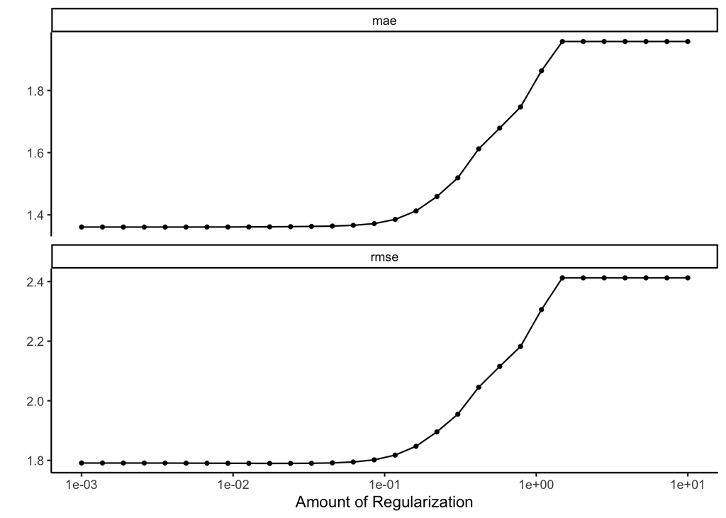

```r
# Lasso Model Spec with tune
gam_lasso_spec_tune <-
  linear_reg() %>%
  set_args(mixture = 1, penalty = tune()) %>% ## mixture = 1 indicates Lasso
  set_engine(engine = 'glmnet') %>% #note we are using a different engine
  set_mode('regression')

# Recipe with standardization (!) --> just include all these always
data_rec <- recipe(Gross ~ ., data = imdb_clean) %>%
    step_rm(Series_Title, Released_Year, Overview,
            Director, Star1, Star2, Star3, Star4, Genre_2, Genre_3) %>%
    step_nzv(all_predictors()) %>% # removes variables with the same value (so duplicates don't mess up model)
    step_novel(all_nominal_predictors()) %>% # important if you have rare categorical variables
    step_normalize(all_numeric_predictors()) %>%  # super important standardization step for LASSO
    step_dummy(all_nominal_predictors()) %>%  # creates indicator variables for categorical variables
    step_naomit(Gross)

# Workflow (Recipe + Model)
lasso_wf_tune1 <- workflow() %>%
  add_recipe(data_rec) %>%
  add_model(gam_lasso_spec_tune)

# Tune Model (trying a variety of values of Lambda penalty)
penalty_grid <- grid_regular(
  penalty(range = c(-3, 1)),
  levels = 30)

tune_res1 <- tune_grid( # new function for tuning parameters
  lasso_wf_tune1, # workflow
  resamples = data_cv10, # cv folds
  metrics = metric_set(rmse, mae),
  grid = penalty_grid # penalty grid defined above
)

# Visualize Model Evaluation Metrics from Tuning
autoplot(tune_res1) + theme_classic()
```

# Collect CV Metrics and Select Best Model

```r
# Summarize Model Evaluation Metrics (CV)
collect_metrics(tune_res) %>%
  filter(.metric == 'rmse') %>% # or choose mae
  select(penalty, rmse = mean)
```

| penalty | rmse |
| --- | --- |
| 0.001000000 | 1.791129 |
| 0.001373824 | 1.791129 |
| 0.001887392 | 1.791129 |
| 0.002592944 | 1.791108 |
| 0.003562248 | 1.790977 |
| 0.004893901 | 1.790812 |
| 0.006723358 | 1.790577 |
| 0.009236709 | 1.790305 |
| 0.012689610 | 1.790023 |
| 0.017433288 | 1.789810 |

[output cut: 20 more lines]

```r
best_penalty1 <- select_best(tune_res1, metric = 'rmse') # choose penalty value based on lowest mae or rmse
```

# Fit Final Model

```r
# Fit Final Model
final_wf1 <- finalize_workflow(lasso_wf_tune1, best_penalty) # incorporates penalty value to workflow

final_fit1 <- fit(final_wf1, data = imdb_clean)

tidy(final_fit1)
```

| term | estimate | penalty |
| --- | --- | --- |
| (Intercept) | 16.25867291 | 0.01743329 |
| Runtime | 0.31320626 | 0.01743329 |
| IMDB_Rating | -0.98112595 | 0.01743329 |
| Meta_score | 0.00000000 | 0.01743329 |
| No_of_Votes | 1.68100163 | 0.01743329 |
| Genre_1_Adventure | 0.21379158 | 0.01743329 |
| Genre_1_Animation | 0.68189096 | 0.01743329 |
| Genre_1_Biography | 0.56984397 | 0.01743329 |
| Genre_1_Comedy | -0.03005227 | 0.01743329 |
| Genre_1_Crime | -0.74108695 | 0.01743329 |

[output cut: 9 more lines]

```r
# Final ("best") model predictors and coefficients

final_fit1 %>% tidy() %>% filter(estimate != 0)
```

| term | estimate | penalty |
| --- | --- | --- |
| (Intercept) | 16.25867291 | 0.01743329 |
| Runtime | 0.31320626 | 0.01743329 |
| IMDB_Rating | -0.98112595 | 0.01743329 |
| No_of_Votes | 1.68100163 | 0.01743329 |
| Genre_1_Adventure | 0.21379158 | 0.01743329 |
| Genre_1_Animation | 0.68189096 | 0.01743329 |
| Genre_1_Biography | 0.56984397 | 0.01743329 |
| Genre_1_Comedy | -0.03005227 | 0.01743329 |
| Genre_1_Crime | -0.74108695 | 0.01743329 |
| Genre_1_Drama | -0.39102430 | 0.01743329 |

[output cut: 6 more lines]

# Visualize Residuals

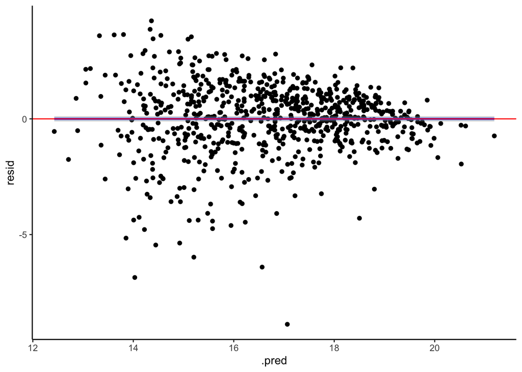

```r
# Visualize Residuals
lasso_mod_out1 <- new_mod %>%
    predict(new_data = imdb_clean) %>%
    bind_cols(imdb_clean) %>%
    mutate(resid = Gross - .pred)


ggplot(lasso_mod_out1, aes(x = .pred, y = resid)) +
    geom_point() +
    geom_smooth() +
    geom_hline(yintercept = 0, color = "red") +
    theme_classic()
```

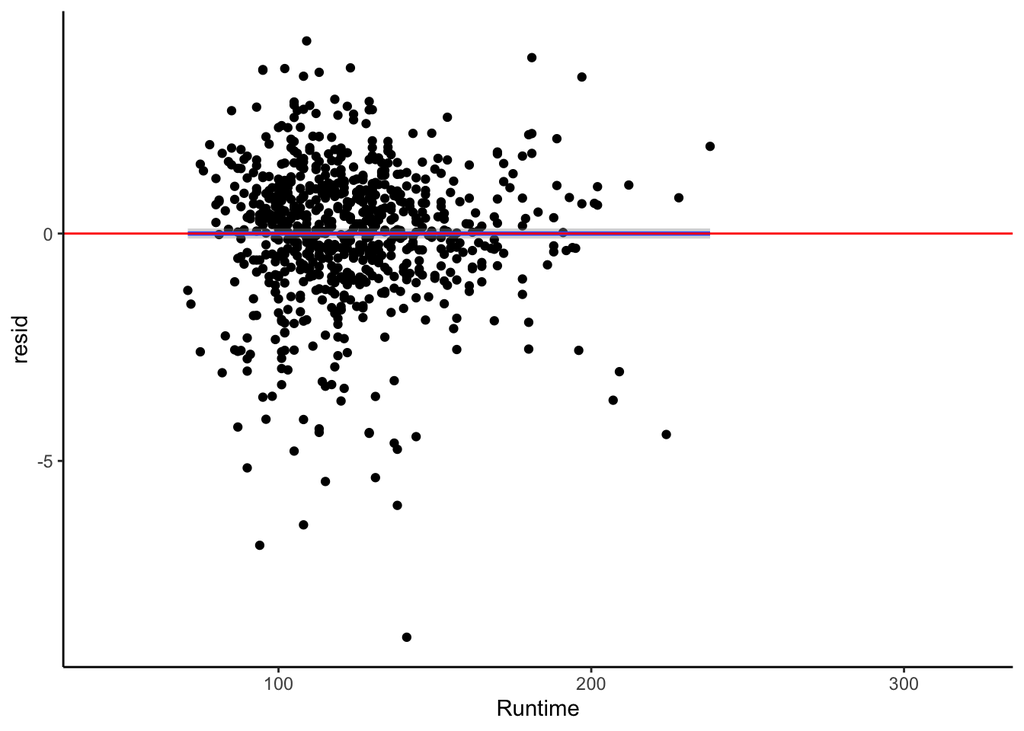

```r
ggplot(lasso_mod_out1, aes(x = Runtime, y = resid)) +
    geom_point() +
    geom_smooth() +
    geom_hline(yintercept = 0, color = "red") +
    theme_classic()
```

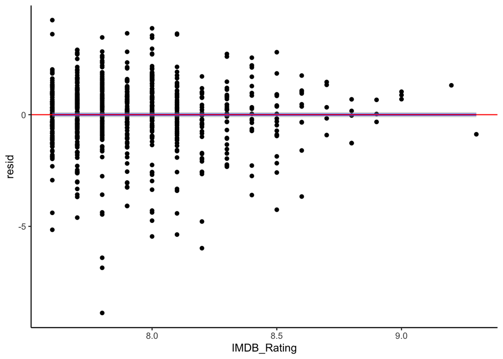

```r
ggplot(lasso_mod_out1, aes(x = IMDB_Rating, y = resid)) +
    geom_point() +
    geom_smooth() +
    geom_hline(yintercept = 0, color = "red") +
    theme_classic()
```

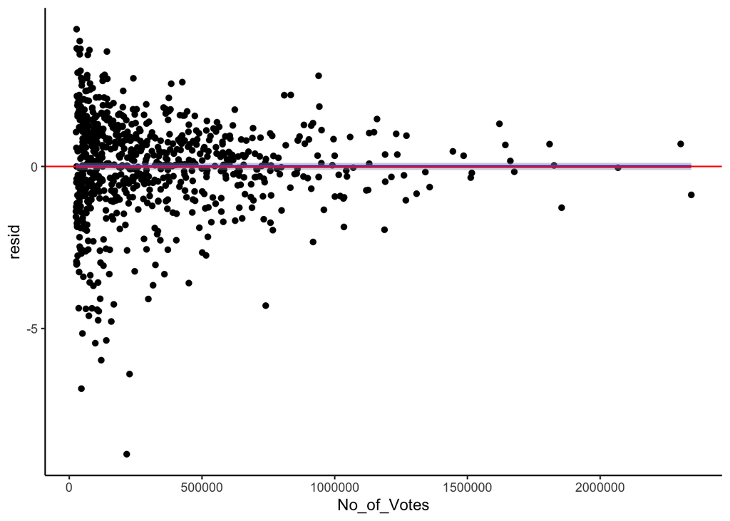

```r
ggplot(lasso_mod_out1, aes(x = No_of_Votes, y = resid)) +
    geom_point() +
    geom_smooth() +
    geom_hline(yintercept = 0, color = "red") +
    theme_classic()
```

# Comparing Model Performance

```r
full_modelcv %>% collect_metrics() #OLS
```

| .metric | .estimator | mean | n | std_err | .config |
| --- | --- | --- | --- | --- | --- |
| mae | standard | 1.2881368 | 10 | 0.03784742 | Preprocessor1_Model1 |
| rmse | standard | 1.7064888 | 10 | 0.05700728 | Preprocessor1_Model1 |
| rsq | standard | 0.4207767 | 10 | 0.02114632 | Preprocessor1_Model1 |

```r
lasso_fit %>% collect_metrics() #LASSO
```

| .metric | .estimator | mean | n | std_err | .config |
| --- | --- | --- | --- | --- | --- |
| mae | standard | 1.3613193 | 10 | 0.03846888 | Preprocessor1_Model1 |
| rmse | standard | 1.7898097 | 10 | 0.05554757 | Preprocessor1_Model1 |
| rsq | standard | 0.4453716 | 10 | 0.01542887 | Preprocessor1_Model1 |

```r
new_modcv %>% collect_metrics() #GAM
```

| .metric | .estimator | mean | n | std_err | .config |
| --- | --- | --- | --- | --- | --- |
| mae | standard | 1.1628028 | 10 | 0.03399182 | Preprocessor1_Model1 |
| rmse | standard | 1.5892078 | 10 | 0.05245617 | Preprocessor1_Model1 |
| rsq | standard | 0.4967594 | 10 | 0.01698366 | Preprocessor1_Model1 |

# Summarize Investigations

The goal of our investigations is to accurately predict a movie’s gross box office revenue based on a number of predictors. We compared three different model types: ordinary linear regression (OLS) with all predictors, OLS using LASSO to select a subset of variables, and a GAM using splines to account for nonlinearity. The GAM model has the lowest RMSE but could be difficult to interpret. We are looking forward to continuing our investigations using Decision Trees which may offer a more easily interpreted method for modeling nonlinearity. Ideally, we would like an accurate model that is relatively easy to interpret.

# Societal Impact

In addition to our earlier discussion of societal impacts that our model may have, we want to keep in mind the biases of the Hollywood movie industry. Representation of different races, genders, abilities, etc. is an issue in Hollywood/the greater film industry, and it is likely that the harm our model/analysis produces is already in line with the issues that created and maintain this. This is because the data we have is from past movies that came out of this system. This means that whatever made a movie successful, whether it’s due to certain actors, directors, etc., is a standard that already existed. If we see the movies that have done really well have predominantly white casts, then it is likely a result of a longstanding issue of racism in the movie industry. Our model can’t account for that, but we are aware of it.